# Group_3-Report

Abrar Usman, Alexandros Ioannou, Anil Isilak, Benjamin Strain, Rupesh Rangwani, Shayaan Niazi

2022-12-13

## Table of Contents

- Introduction
- Data Description
- Descriptive Statistics
- Conlusion

## Introduction

The current climate situation is one of increasing global warming, which is being caused by the emission of greenhouse gases into the atmosphere. These emissions are primarily the result of human activities, such as the burning of fossil fuels for energy and transportation, and deforestation. A potential effect of global warming is the melting of polar ice caps, which can cause sea levels to rise. This can lead to flooding in coastal areas and the displacement of people living in those areas. In addition, warmer temperatures can lead to more extreme weather events, such as heatwaves, droughts, and hurricanes.

In the following report, we have carried out an analysis to see the how the increase of various factors have had a major contribution to climate change and global warming.

## Data Description

We have decided on using 6 data sets for this report which we think are the main contributors to the change in climate. The data sets are: Biofuel, Coal, Electricity, and Sea Ice, Natural Gas, Petro Liquids. These data sets have the following variables: Years, Production/Generation, Emission, Consumption, Sea Ice Index, and Sea Ice rates of change. Most of these variables are continuous except the Years variable which is categorical. Also, we have decided to take into consideration 6 of the countries provided in these data sets, which correspond to one of the largest contributors in each region of the world, and the last 21 years (2000-2021). The countries are: Canada, USA, China, Germany, Brazil, France. We have also included the general contribution of the world.

## Descriptive Statistics

### Biofuel

#### Production

This graph shows the total production of biofuel across 6 of the worlds biggest producers of the biofuel.

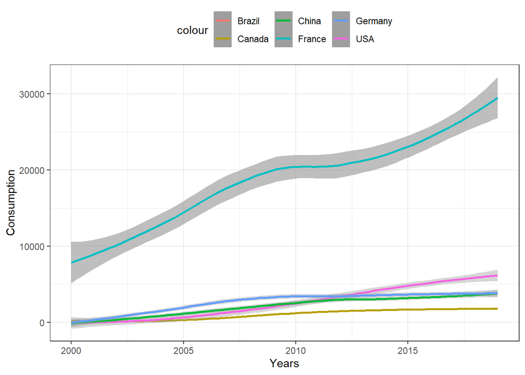

#### Consumption

This graph shows the total consumption of biofuel across 6 of the worlds biggest producers of the biofuel.

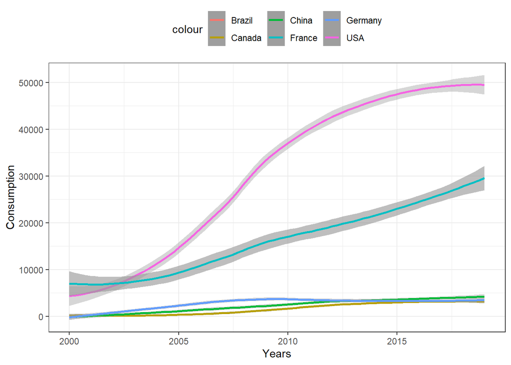

#### Correlation

```
##
## Call:
## lm(formula = consumption ~ production, data = World)
##
## Residuals:
##      Min       1Q   Median       3Q      Max
## -12907.7  -2877.5   -555.4   2089.9  10552.9
##
## Coefficients:
##               Estimate Std. Error t value Pr(>|t|)
## (Intercept) -3.622e+03  2.652e+03  -1.366    0.189
## production   1.712e+00  5.656e-02  30.267   <2e-16 ***
## ---
## Signif. codes:  0 '***' 0.001 '**' 0.01 '*' 0.05 '.' 0.1 ' ' 1
##
## Residual standard error: 5637 on 18 degrees of freedom
## Multiple R-squared:  0.9807, Adjusted R-squared:  0.9797
## F-statistic: 916.1 on 1 and 18 DF,  p-value: < 2.2e-16
```

#### Production and Consumption

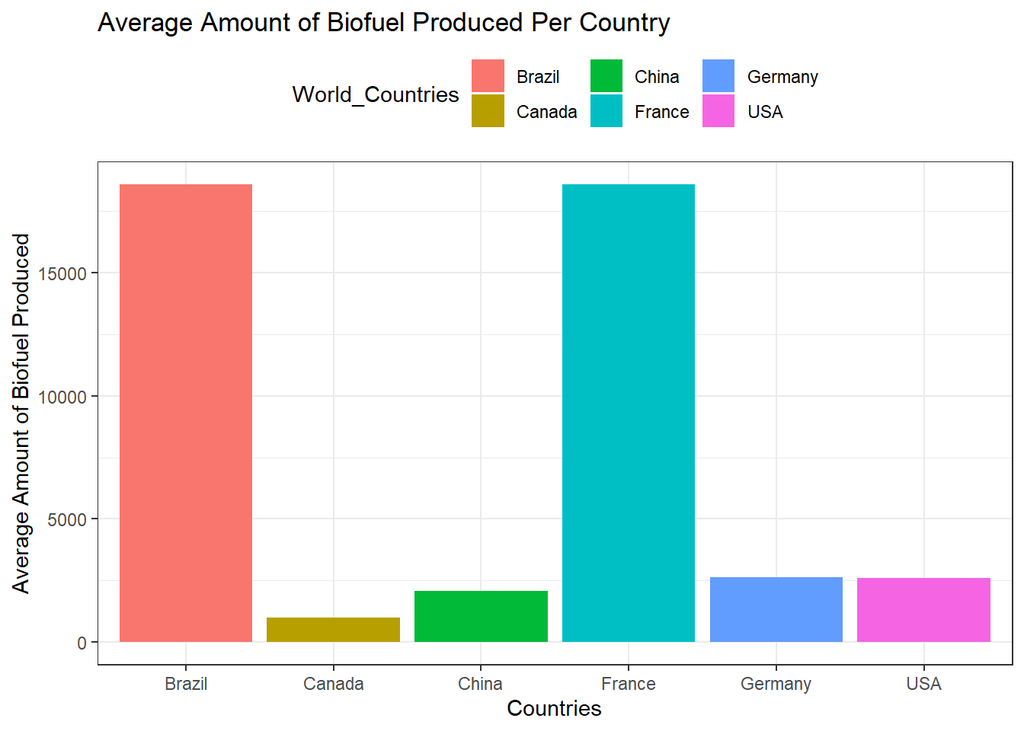

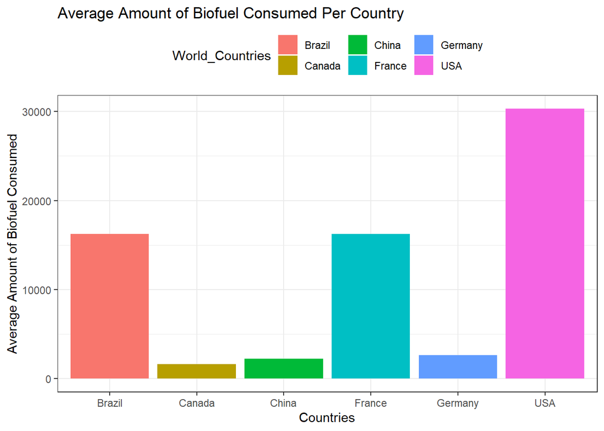

### Coal

The production of coal has had a significant impact on the climate. When coal is burned, it releases large amounts of carbon dioxide and other greenhouse gases into the atmosphere. These gases trap heat from the sun and warm the Earth’s surface, leading to a phenomenon known as global warming. As the Earth’s temperature increases, it can cause a range of impacts, including more frequent and severe heatwaves, droughts, and storms. It can also cause sea levels to rise, which can lead to flooding and other coastal impacts.

#### Total Coal Emissions of the World

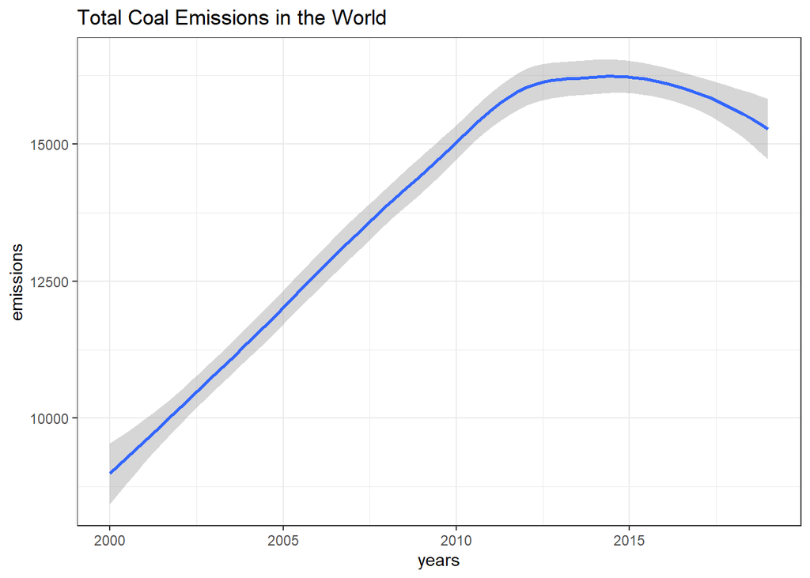

#### Total Coal Production of each Country

Overall, the production of coal has been the highest in China since 2000 whereas the production of coal in the remaining countries is significantly less. China’s large population and rapid economic growth have led to an increased demand for energy, which has made coal an attractive option for meeting the country’s energy needs. Additionally, China has a large and well-developed coal mining industry, which has made it easier for the country to produce coal in large quantities.

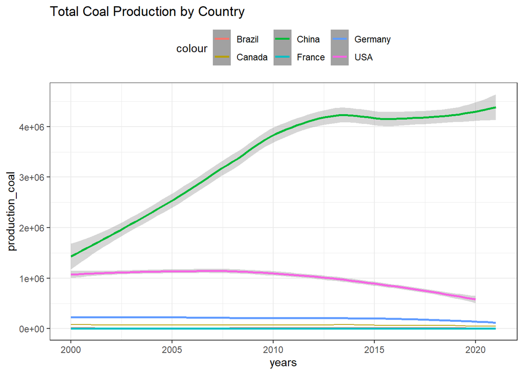

### Electricity

Electricity plays a significant role in climate change. The production of electricity is a major source of greenhouse gas emissions, which contribute to global warming.There are several ways in which electricity production affects climate change. First, the burning of fossil fuels such as coal, natural gas, and oil to generate electricity produces large amounts of carbon dioxide (CO2) and other greenhouse gases. These gases trap heat in the atmosphere, causing the earth’s temperature to rise.

In the graphs below, the main focus is the generation of electricity from the countries. The total generation consists nuclear, fossil fuels, renewables, and hydropump storage. These are the factors that have the most contribution to climate change.

#### Total Generation by Country

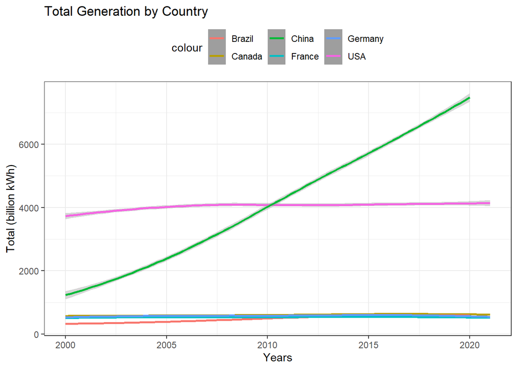

#### Total Nuclear Generation by Country

Here we can see a graph of the total nuclear electricity by country. The generation of nuclear electricity has a minimal impact on climate change compared to other forms of electricity generation. Nuclear power plants do not produce greenhouse gas emissions when they generate electricity, unlike fossil fuel-based power plants, which release large amounts of carbon dioxide (CO2) and other greenhouse gases into the atmosphere. USA has the largest contribution of nuclear generation by far, with France being the second largest. Overall, nuclear generation seems to be neutral by most countries over the past 21 years with the exception of China which has seen an exponential increase from 2013-2021.

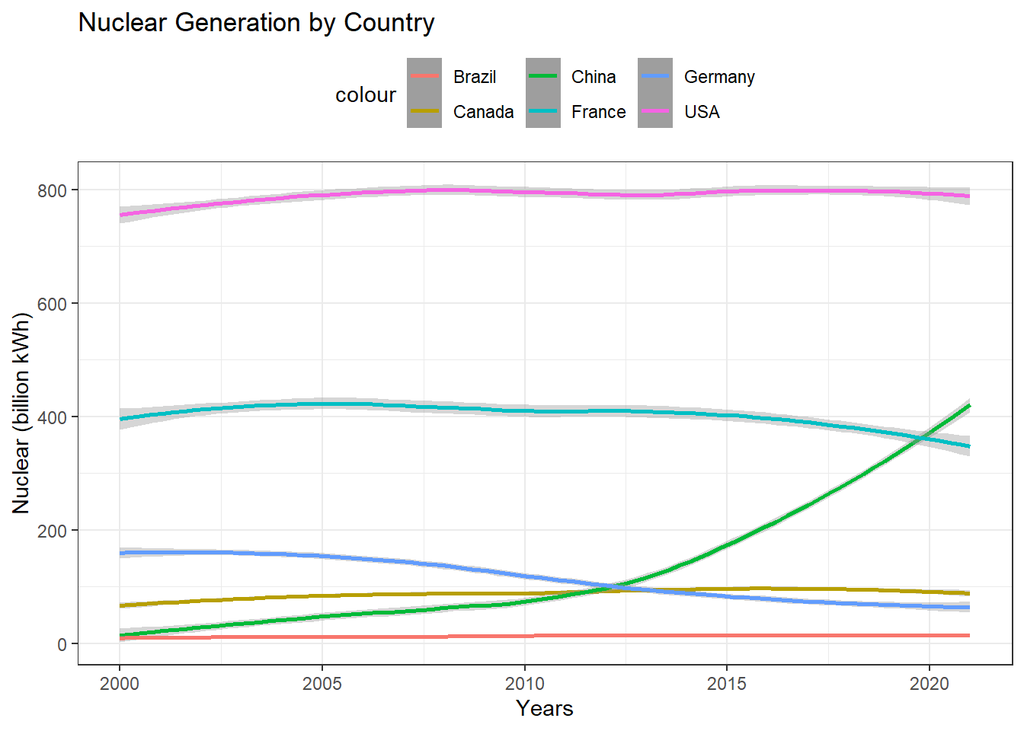

#### Total Fossil Fuel Generation by Country

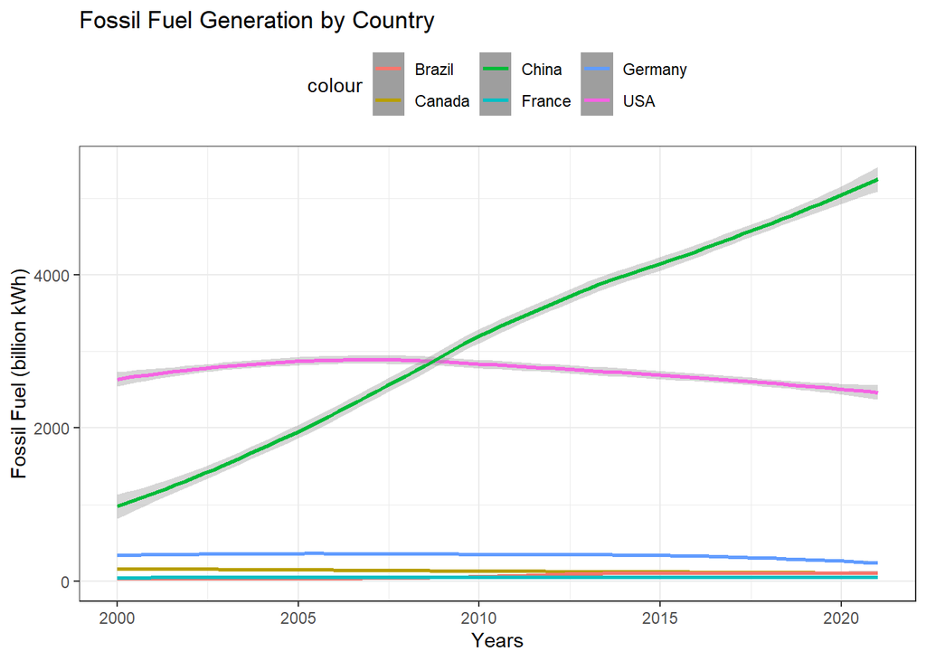

### Sea Ice

Sea ice plays a crucial role in the Earth’s climate system. When sunlight hits the Earth’s surface, some of it is reflected back into the atmosphere by bright surfaces like snow and ice. This process, known as albedo, helps to cool the planet. Sea ice has a particularly high albedo, so when it covers a large area of the ocean, it reflects a significant amount of sunlight back into space. This helps to keep the Earth’s temperature in balance. However, as the Earth’s temperature increases due to climate change, sea ice is melting at an alarming rate. As the ice melts, it exposes the dark ocean surface, which absorbs more heat from the sun. This causes the ocean to warm, which in turn causes more ice to melt. This feedback loop can accelerate the warming of the planet, leading to even more severe impacts of climate change. Therefore, the loss of sea ice can exacerbate the effects of climate change, making it even more important to reduce greenhouse gas emissions and slow global warming.

#### Sea Ice Index Monthly Data by Year

(In millions of square kilometers)

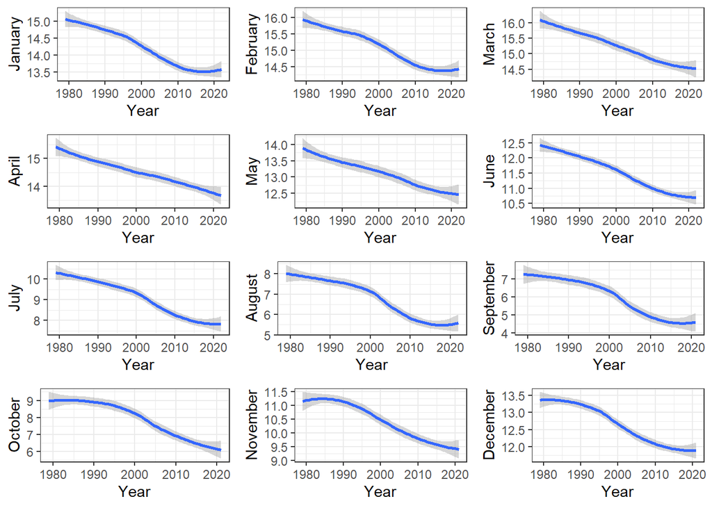

#### Sea Ice Index Annual Data by Year

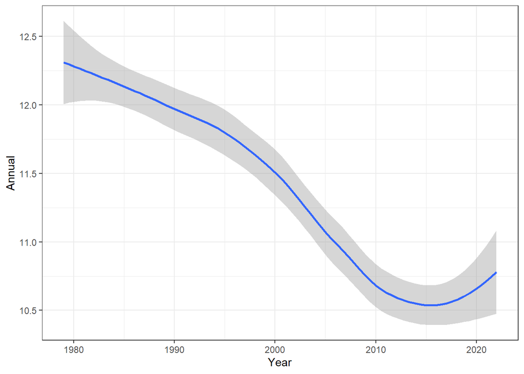

## Natural Gas

Natural gas is a fossil fuel formed over millions of years from the decomposition of organic materials. It is a colorless, odorless, and tasteless hydrocarbon gas mixture, primarily consisting of methane, along with smaller amounts of other hydrocarbons such as ethane, propane, and butane. Natural gas is often referred to as “the cleanest burning fossil fuel” because it produces fewer air pollutants and greenhouse gases than other fossil fuels when burned. It is commonly used for heating, cooking, and electricity generation, and is also used as a raw material in the production of various products.

When burned, it produces fewer air pollutants and greenhouse gases than other fossil fuels such as coal and oil. However, the extraction and transportation of natural gas can still have environmental impacts, such as air and water pollution and the potential for accidents and leaks. In addition, the extraction of natural gas, particularly through the process of hydraulic fracturing or “fracking,” has been linked to increased levels of methane in the atmosphere. Methane is a potent greenhouse gas, with a global warming potential that is more than 25 times greater than carbon dioxide over a 100-year time horizon.

While natural gas can play a role in reducing greenhouse gas emissions in the short term, its long-term use as a primary energy source may not be sustainable in the context of addressing climate change. Increasing the use of renewable energy sources, such as wind and solar power, is seen as a more effective and sustainable way to reduce greenhouse gas emissions and combat climate change.

```
## [1] "Years Chosen"
```

```
##  [1] "2000" "2001" "2002" "2003" "2004" "2005" "2006" "2007" "2008" "2009"
## [11] "2010" "2011" "2012" "2013" "2014" "2015" "2016" "2017" "2018" "2019"
## [21] "2020" "2021"
```

```
## [1] "World Gross Natural Gas"
```

```
##  [1] "107796.54341134097" "109969.83176915186" "112346.84702023618"
##  [4] "115643.42667626927" "119720.39742404464" "125016.49442553897"
##  [7] "127905.89121790144" "132975.8642607746"  "137717.9118556122"
## [10] "134983.1857498825"  "143088.3431406046"  "146520.57920740114"
## [13] "148389.2651471526"  "149766.31430938683" "152228.79321201623"
## [16] "154397.73364052683" "\""                 "\""
## [19] "\""                 "\""                 "\""
## [22] "\""
```

```
## [1] "World Emmission"
```

```
##  [1] "4736.163826731" "4754.981620364" "4974.681563292" "5119.268510389"
##  [5] "5279.489805772" "5429.202966814" "5630.349601392" "5811.117852225"
##  [9] "5978.147381183" "5782.11737159"  "6324.816534711" "6513.89466993"
## [13] "6662.056920043" "6759.120315845" "6783.647503147" "6883.268116663"
## [17] "7023.602020587" "7253.923510471" "7607.936617844" "7768.089520043"
## [21] "\""             "\""
```

```
## [1] "Canada Natural Gas"
```

```
##  [1] "7679.5999"   "7826.5103"   "7785.89805"  "7608.61675"  "7698.67"
##  [6] "7734.33815"  "7784.55608"  "7625.35606"  "7368.61601"  "6927.67292"
## [11] "6695.335535" "6669.23775"  "6310.29609"  "6456.07641"  "6814.276455"
## [16] "6751.698275" "NA"          "NA"          "\""          "\""
## [21] "\""          "\""
```

```
## [1] "Canada Emmission"
```

```
##  [1] "161.885663913" "169.255727934" "172.074486493" "183.430640532"
##  [5] "181.69255311"  "171.319180825" "179.938310679" "166.381672853"
##  [9] "160.04286498"  "170.209203206" "188.488833405" "195.265614452"
## [13] "205.056455677" "218.336165116" "226.864371923" "225.554874505"
## [17] "216.016296601" "230.934963008" "245.386044681" "244.660473734"
## [21] "\""            "\""
```

```
## [1] "US Natural Gas"
```

```
##  [1] "24173.875492" "24500.778781" "23941.278948" "24118.978071" "23969.678466"
##  [6] "23456.821656" "23535.018414" "24663.655757" "25636.256778" "26056.893025"
## [11] "26816.085479" "28479.025837" "29542.313072" "29522.55073"  "31405.381234"
## [16] "32914.647015" "32591.577934" "33292.112552" "\""           "\""
## [21] "\""           "\""
```

```
## [1] "US Emmission"
```

```
##  [1] "1246.049927" "1191.759702" "1231.52727"  "1195.380899" "1200.931081"
##  [6] "1182.46557"  "1169.696029" "1245.157609" "1254.522337" "1233.390342"
## [11] "1292.438107" "1312.327965" "1371.560957" "1408.379797" "1437.536155"
## [16] "1478.884313" "1489.851251" "1470.964449" "1626.410978" "1684.007856"
## [21] "\""          "\""
```

```
## [1] "China Natural Gas"
```

```
##  [1] "962.33375"   "1070.39765"  "1152.6816"   "1211.3045"   "1439.79255"
##  [6] "1762.9248"   "2066.56317"  "2446.27005"  "2685.3526"   "2975.00623"
## [11] "3334.08915"  "3628.651565" "3665.55574"  "3986.00405"  "4359.91927"
## [16] "4559.625595" "NA"          "NA"          "\""          "\""
## [21] "\""          "\""
```

```
## [1] "China Emmission"
```

```
##  [1] "50.031135696"  "54.015691157"  "58.842191998"  "63.3965291"
##  [5] "74.866566393"  "91.732886168"  "110.525890254" "138.059462192"
##  [9] "151.117447631" "173.278233238" "208.939515111" "256.348872054"
## [13] "281.319405614" "319.365546727" "354.690050448" "373.591538352"
## [17] "405.480667677" "467.168069473" "548.698591813" "600.276259436"
## [21] "\""            "\""
```

```
## [1] "Germany Natural Gas"
```

```
##  [1] "835.800105" "841.76834"  "843.710665" "816.97721"  "746.947565"
##  [6] "738.0835"   "767.0418"   "757.400805" "672.68012"  "663.109755"
## [11] "568.677445" "561.473185" "497.09394"  "464.851345" "367.34663"
## [16] "337.25825"  "NA"         "NA"         "\""         "\""
## [21] "\""         "\""
```

```
## [1] "Germany Emmission"
```

```
##  [1] "161.416857634" "168.778576211" "168.396383411" "170.554259347"
##  [5] "171.722456454" "173.316372323" "176.926861205" "169.73773253"
##  [9] "176.903908426" "164.458859598" "181.569178412" "164.630525354"
## [13] "164.822119459" "168.803220031" "152.713734723" "157.124122161"
## [17] "169.858274238" "180.305571156" "179.713748887" "192.181358751"
## [21] "\""            "\""
```

```
## [1] "Brazil Natural Gas"
```

```
##  [1] "469.33635"       "494.41"          "548.44195"       "557.62385"
##  [5] "599.29555"       "625.0755"        "625.42865"       "640.96725"
##  [9] "762.45085"       "746.241265"      "809.77295"       "850.03205"
## [13] "912.04519"       "994.788235"      "1126.301295"     "1238.1439"
## [17] "1338.0898846726" "1416.7333275432" "\""              "\""
## [21] "\""              "\""
```

```
## [1] "Brazil Emmission"
```

```
##  [1] "18.395199649" "21.863786024" "26.092343571" "27.553826594" "33.555650208"
##  [6] "36.891916158" "38.339046668" "39.369879361" "46.883063791" "37.10997692"
## [11] "49.955738162" "49.678206283" "59.966709499" "70.808294103" "74.899906943"
## [16] "78.085576436" "66.648896174" "68.087097439" "64.86363154"  "64.315798443"
## [21] "\""           "\""
```

```
## [1] "France Natural Gas"
```

```
##  [1] "66.32157"  "67.45165"  "95.70365"  "84.0497"   "77.33985"  "63.21385"
##  [7] "65.33275"  "57.56345"  "51.91305"  "48.7347"   "47.67525"  "39.5528"
## [13] "36.127245" "12.0071"   "0.600355"  "0.741615"  "NA"        "NA"
## [19] "\""        "\""        "\""        "\""
```

```
## [1] "France Emmission"
```

```
##  [1] "83.658008843"  "87.716337344"  "89.911990743"  "88.252551718"
##  [5] "93.678082597"  "99.814943496"  "102.119664749" "94.994335429"
##  [9] "99.592142283"  "95.255865942"  "96.927019799"  "93.781112976"
## [13] "87.389509399"  "91.252077525"  "74.927107411"  "78.973037739"
## [17] "86.480272045"  "86.978677643"  "83.045619528"  "85.589064536"
## [21] "\""            "\""
```

## Petro Liquids

```r
#petro_liquids_df <- INT_Export_PetroLiquids_09_09_2022_23_10_18
petro_liquids_col <- data$`Report generated on: 09-09-2022 23:10:18`
```

```r
#Tidying up the data
Years <- str_split(petro_liquids_col[1], ",")
Years_2 <- Years[[1]]
Years_3 <- Years_2[54:75]

# Production of Worlds PL
print("Production")
```

```
## [1] "Production"
```

```r
PL_Production <- str_split(petro_liquids_col[4], ",")
World_Unlist_Production <- PL_Production[[1]]
World_PL_Production <- World_Unlist_Production[54:75]
World_PL_Production
```

```
##  [1] "77729.13101662204"  "77673.20602621877"  "77103.67161292638"
##  [4] "79623.38939435485"  "83519.8086748634"   "85158.96515342465"
##  [7] "85278.85240547945"  "85330.45576438356"  "86433.03738197268"
## [10] "85123.22327435616"  "87317.27822534885"  "88481.5641186452"
## [13] "90769.35775997322"  "91305.82011806667"  "93899.4744094"
## [16] "96629.23577778492"  "97116.43366496103"  "97797.04021960973"
## [19] "100487.34542312133" "100234.96631206493" "93864.55076729569"
## [22] "95667.57251507363"
```

```r
# Emission of Worlds PL
print("Emissions")
```

```
## [1] "Emissions"
```

```r
PL_emissions <- str_split(petro_liquids_col[37], ",")
World_Unlist_Production <- PL_emissions[[1]]
World_PL_Emissions <- World_Unlist_Production[54:75]
World_PL_Emissions
```

```
##  [1] "10149.458185069314" "10240.675971804989" "10327.148336304794"
##  [4] "10526.1424499044"   "10891.981599328534" "11063.949097606172"
##  [7] "11132.627421518873" "10772.087378167133" "11068.32062699947"
## [10] "10972.530742525249" "11192.606607317048" "11308.436594940287"
## [13] "11467.370701808617" "11608.05198857437"  "11728.324300353772"
## [16] "11942.133207106728" "12034.589361049557" "12140.459510229892"
## [19] "12203.922539102654" "12192.755896281456" "\""
## [22] "\""
```

```r
WorldPL <- tibble(years = Years_3, World_PL_Production= World_PL_Production, World_PL_Emissions= World_PL_Emissions)
WorldPL
```

```
## # A tibble: 22 × 3
##    years World_PL_Production World_PL_Emissions
##    <chr> <chr>               <chr>
##  1 2000  77729.13101662204   10149.458185069314
##  2 2001  77673.20602621877   10240.675971804989
##  3 2002  77103.67161292638   10327.148336304794
##  4 2003  79623.38939435485   10526.1424499044
##  5 2004  83519.8086748634    10891.981599328534
##  6 2005  85158.96515342465   11063.949097606172
##  7 2006  85278.85240547945   11132.627421518873
##  8 2007  85330.45576438356   10772.087378167133
##  9 2008  86433.03738197268   11068.32062699947
## 10 2009  85123.22327435616   10972.530742525249
## # … with 12 more rows
```

```r
WorldPL$years <- as.integer(WorldPL$years)
WorldPL$World_PL_Production <- as.double(WorldPL$World_PL_Production)
WorldPL$World_PL_Emissions <- as.double(WorldPL$World_PL_Emissions)
Years <- str_split(petro_liquids_col[1], ",")
Years_2 <- Years[[1]]
Years_3 <- Years_2[54:75]

# Production of Canada's PL
print("Production")
```

```
## [1] "Production"
```

```r
Canada_PL_Production <- str_split(petro_liquids_col[1300], ",")
Canada_Production <- Canada_PL_Production[[1]]
Canada_PL_Production <- Canada_Production[54:75]
Canada_PL_Production
```

```
##  [1] "2753.144554644809"  "2816.3618479452057" "2953.699680821918"
##  [4] "3113.6452102739727" "3139.358081967213"  "3096.28461369863"
##  [7] "3292.0780767123288" "3448.5232328767124" "3345.1750967213115"
## [10] "3308.373717808219"  "3429.9934739726027" "3583.7165712328765"
## [13] "3842.1190355191256" "4056.8524876712327" "4378.220669863013"
## [16] "4493.867161643836"  "4576.818819672131"  "4946.555156164383"
## [19] "5348.1455602739725" "5477.585794520548"  "5234.650101639344"
## [22] "5538.453742836614"
```

```r
# Emission of Canada's PL
print("Emissions")
```

```
## [1] "Emissions"
```

```r
Canada_PL_Emissions <- str_split(petro_liquids_col[1333], ",")
Canada_Emissions <- Canada_PL_Emissions[[1]]
Canada_PL_Emissions <- Canada_Emissions[54:75]
Canada_PL_Emissions
```

```
##  [1] "236.524755312" "241.40650648"  "253.742252044" "269.845294464"
##  [5] "276.340910304" "288.366347436" "283.808711036" "298.139379344"
##  [9] "287.48029276"  "280.752884652" "290.053379576" "292.187893948"
## [13] "292.58822182"  "293.16098882"  "287.603725744" "294.03209922"
## [17] "292.722831244" "299.628819204" "308.283715928" "311.336489104"
## [21] "\""            "\""
```

```r
CanadaPL <- tibble(years = Years_3, Canada_PL_Production= Canada_PL_Production, Canada_PL_Emissions= Canada_PL_Emissions)
CanadaPL
```

```
## # A tibble: 22 × 3
##    years Canada_PL_Production Canada_PL_Emissions
##    <chr> <chr>                <chr>
##  1 2000  2753.144554644809    236.524755312
##  2 2001  2816.3618479452057   241.40650648
##  3 2002  2953.699680821918    253.742252044
##  4 2003  3113.6452102739727   269.845294464
##  5 2004  3139.358081967213    276.340910304
##  6 2005  3096.28461369863     288.366347436
##  7 2006  3292.0780767123288   283.808711036
##  8 2007  3448.5232328767124   298.139379344
##  9 2008  3345.1750967213115   287.48029276
## 10 2009  3308.373717808219    280.752884652
## # … with 12 more rows
```

```r
CanadaPL$years <- as.integer(CanadaPL$years)
CanadaPL$Canada_PL_Production <- as.double(CanadaPL$Canada_PL_Production)
CanadaPL$Canada_PL_Emissions <- as.double(CanadaPL$Canada_PL_Emissions)
Years <- str_split(petro_liquids_col[1], ",")
Years_2 <- Years[[1]]
Years_3 <- Years_2[54:75]

# Production of USA's PL
print("Production")
```

```
## [1] "Production"
```

```r
USA_PL_Production <- str_split(petro_liquids_col[7924], ",")
USA_Production <- USA_PL_Production[[1]]
USA_PL_Production <- USA_Production[54:75]
USA_PL_Production
```

```
##  [1] "9057.775957349726"  "8957.008215561644"  "8998.432876712326"
##  [4] "8765.83287671233"   "8722.267950819672"  "8327.13702739726"
##  [7] "8314.320495890412"  "8466.32037260274"   "8563.53169398907"
## [10] "9136.949257534246"  "9698.1130630137"    "10150.896002739726"
## [13] "11142.537295081967" "12395.427780821918" "14157.73210410959"
## [16] "15154.876602739727" "14849.860792349727" "15673.331663013698"
## [19] "17909.764"          "19471.199202739725" "18609.48106010929"
## [22] "18944.21390136986"
```

```r
# Emission of USA PL
print("Emissions")
```

```
## [1] "Emissions"
```

```r
USA_PL_Emissions <- str_split(petro_liquids_col[7957], ",")
USA_Emissions <- USA_PL_Emissions[[1]]
USA_PL_Emissions <- USA_Emissions[54:75]
USA_PL_Emissions
```

```
##  [1] "2487.799439" "2498.772328" "2495.620909" "2557.114465" "2634.422093"
##  [6] "2644.38246"  "2613.624554" "2599.085012" "2429.910868" "2295.114893"
## [11] "2315.285504" "2266.767453" "2206.888316" "2232.64589"  "2262.975549"
## [16] "2301.293482" "2324.44547"  "2342.164543" "2388.226367" "2382.83304"
## [21] "\""          "\""
```

```r
USAPL <- tibble(years = Years_3, USA_PL_Production= USA_PL_Production, USA_PL_Emissions= USA_PL_Emissions)
USAPL
```

```
## # A tibble: 22 × 3
##    years USA_PL_Production USA_PL_Emissions
##    <chr> <chr>             <chr>
##  1 2000  9057.775957349726 2487.799439
##  2 2001  8957.008215561644 2498.772328
##  3 2002  8998.432876712326 2495.620909
##  4 2003  8765.83287671233  2557.114465
##  5 2004  8722.267950819672 2634.422093
##  6 2005  8327.13702739726  2644.38246
##  7 2006  8314.320495890412 2613.624554
##  8 2007  8466.32037260274  2599.085012
##  9 2008  8563.53169398907  2429.910868
## 10 2009  9136.949257534246 2295.114893
## # … with 12 more rows
```

```r
USAPL$years <- as.integer(USAPL$years)
USAPL$USA_PL_Production <- as.double(USAPL$USA_PL_Production)
USAPL$USA_PL_Emissions <- as.double(USAPL$USA_PL_Emissions)
Years <- str_split(petro_liquids_col[1], ",")
Years_2 <- Years[[1]]
Years_3 <- Years_2[54:75]

# Production of China's PL
print("Production")
```

```
## [1] "Production"
```

```r
China_PL_Production <- str_split(petro_liquids_col[1480], ",")
China_Production <- China_PL_Production[[1]]
China_PL_Production <- China_Production[54:75]
China_PL_Production
```

```
##  [1] "3388.5273186951963" "3444.6348642788507" "3549.8615359097425"
##  [4] "3602.9059855313385" "3722.7522076502732" "3871.515917808219"
##  [7] "3980.2150684931507" "4083.0112328767123" "4169.733267213115"
## [10] "4196.292306849315"  "4557.519473972603"  "4616.179716438356"
## [13] "4707.142516939891"  "4840.534912328767"  "4982.802594520548"
## [16] "5103.410150684931"  "4838.198454644808"  "4737.800817808219"
## [19] "4753.095502739727"  "4862.907565753425"  "4862.585915300547"
## [22] "4993.069739371273"
```

```r
# Emission of China's PL
print("Emissions")
```

```
## [1] "Emissions"
```

```r
China_PL_Emissions <- str_split(petro_liquids_col[1513], ",")
China_Emissions <- China_PL_Emissions[[1]]
China_PL_Emissions <- China_Emissions[54:75]
China_PL_Emissions
```

```
##  [1] "643"                "658"                "693"
##  [4] "717"                "850"                "889"
##  [7] "928"                "783.5"              "995"
## [10] "1107"               "1103.0293912097045" "1157.4656835180072"
## [13] "1226.9594329158856" "1299.078628892797"  "1359.8037275138402"
## [16] "1407.2242497243521" "1429.27463244669"   "1491.0671966"
## [19] "1513.6143448"       "1520.5520609460025" "\""
## [22] "\""
```

```r
ChinaPL <- tibble(years = Years_3, China_PL_Production= China_PL_Production, China_PL_Emissions= China_PL_Emissions)
ChinaPL
```

```
## # A tibble: 22 × 3
##    years China_PL_Production China_PL_Emissions
##    <chr> <chr>               <chr>
##  1 2000  3388.5273186951963  643
##  2 2001  3444.6348642788507  658
##  3 2002  3549.8615359097425  693
##  4 2003  3602.9059855313385  717
##  5 2004  3722.7522076502732  850
##  6 2005  3871.515917808219   889
##  7 2006  3980.2150684931507  928
##  8 2007  4083.0112328767123  783.5
##  9 2008  4169.733267213115   995
## 10 2009  4196.292306849315   1107
## # … with 12 more rows
```

```r
ChinaPL$years <- as.integer(ChinaPL$years)
ChinaPL$China_PL_Production <- as.double(ChinaPL$China_PL_Production)
ChinaPL$China_PL_Emissions <- as.double(ChinaPL$China_PL_Emissions)
Years <- str_split(petro_liquids_col[1], ",")
Years_2 <- Years[[1]]
Years_3 <- Years_2[54:75]

# Production of Germany's PL
print("Production")
```

```
## [1] "Production"
```

```r
Germany_PL_Production <- str_split(petro_liquids_col[2848], ",")
Germany_Production <- Germany_PL_Production[[1]]
Germany_PL_Production <- Germany_Production[54:75]
Germany_PL_Production
```

```
##  [1] "150.96042076502738" "146.63111027397258" "154.3158856164384"
##  [4] "160.0749924657534"  "147.34046448087432" "177.50202739726026"
##  [7] "193.18642465753425" "145.46402739726028" "152.01526721311475"
## [10] "148.35620684931507" "205.3683"           "210.3131"
## [13] "203.2896"           "198.59058356164385" "193.9047712328767"
## [16] "186.43361369863013" "172.48243717298908" "165.91460089041095"
## [19] "169.2988294249315"  "162.12985953424658" "185.58012076502732"
## [22] "188.3867192624271"
```

```r
# Emission of China's PL
print("Emissions")
```

```
## [1] "Emissions"
```

```r
Germany_PL_Emissions <- str_split(petro_liquids_col[2881], ",")
Germany_Emissions <- Germany_PL_Emissions[[1]]
Germany_PL_Emissions <- Germany_Emissions[54:75]
Germany_PL_Emissions
```

```
##  [1] "365.720472" "373.421686" "360.443624" "353.786116" "348.084047"
##  [6] "342.626133" "346.328308" "313.165158" "334.543688" "321.186674"
## [11] "325.379913" "315.544455" "317.044603" "322.654846" "312.212123"
## [16] "313.889751" "313.961296" "319.61758"  "311.084081" "316.064203"
## [21] "\""         "\""
```

```r
GermanyPL <- tibble(years = Years_3, Germany_PL_Production= Germany_PL_Production, Germany_PL_Emissions= Germany_PL_Emissions)
GermanyPL
```

```
## # A tibble: 22 × 3
##    years Germany_PL_Production Germany_PL_Emissions
##    <chr> <chr>                 <chr>
##  1 2000  150.96042076502738    365.720472
##  2 2001  146.63111027397258    373.421686
##  3 2002  154.3158856164384     360.443624
##  4 2003  160.0749924657534     353.786116
##  5 2004  147.34046448087432    348.084047
##  6 2005  177.50202739726026    342.626133
##  7 2006  193.18642465753425    346.328308
##  8 2007  145.46402739726028    313.165158
##  9 2008  152.01526721311475    334.543688
## 10 2009  148.35620684931507    321.186674
## # … with 12 more rows
```

```r
GermanyPL$years <- as.integer(GermanyPL$years)
GermanyPL$Germany_PL_Production <- as.double(GermanyPL$Germany_PL_Production)
GermanyPL$Germany_PL_Emissions <- as.double(GermanyPL$Germany_PL_Emissions)
Years <- str_split(petro_liquids_col[1], ",")
Years_2 <- Years[[1]]
Years_3 <- Years_2[54:75]

# Production of Brazil's PL
print("Production")
```

```
## [1] "Production"
```

```r
Brazil_PL_Production <- str_split(petro_liquids_col[2848], ",")
Brazil_Production <- Brazil_PL_Production[[1]]
Brazil_PL_Production <- Brazil_Production[54:75]
Brazil_PL_Production
```

```
##  [1] "150.96042076502738" "146.63111027397258" "154.3158856164384"
##  [4] "160.0749924657534"  "147.34046448087432" "177.50202739726026"
##  [7] "193.18642465753425" "145.46402739726028" "152.01526721311475"
## [10] "148.35620684931507" "205.3683"           "210.3131"
## [13] "203.2896"           "198.59058356164385" "193.9047712328767"
## [16] "186.43361369863013" "172.48243717298908" "165.91460089041095"
## [19] "169.2988294249315"  "162.12985953424658" "185.58012076502732"
## [22] "188.3867192624271"
```

```r
# Emission of China's PL
print("Emissions")
```

```
## [1] "Emissions"
```

```r
Brazil_PL_Emissions <- str_split(petro_liquids_col[2881], ",")
Brazil_Emissions <- Brazil_PL_Emissions[[1]]
Brazil_PL_Emissions <- Brazil_Emissions[54:75]
Brazil_PL_Emissions
```

```
##  [1] "365.720472" "373.421686" "360.443624" "353.786116" "348.084047"
##  [6] "342.626133" "346.328308" "313.165158" "334.543688" "321.186674"
## [11] "325.379913" "315.544455" "317.044603" "322.654846" "312.212123"
## [16] "313.889751" "313.961296" "319.61758"  "311.084081" "316.064203"
## [21] "\""         "\""
```

```r
BrazilPL <- tibble(years = Years_3, Brazil_PL_Production= Brazil_PL_Production, Brazil_PL_Emissions= Brazil_PL_Emissions)
BrazilPL
```

```
## # A tibble: 22 × 3
##    years Brazil_PL_Production Brazil_PL_Emissions
##    <chr> <chr>                <chr>
##  1 2000  150.96042076502738   365.720472
##  2 2001  146.63111027397258   373.421686
##  3 2002  154.3158856164384    360.443624
##  4 2003  160.0749924657534    353.786116
##  5 2004  147.34046448087432   348.084047
##  6 2005  177.50202739726026   342.626133
##  7 2006  193.18642465753425   346.328308
##  8 2007  145.46402739726028   313.165158
##  9 2008  152.01526721311475   334.543688
## 10 2009  148.35620684931507   321.186674
## # … with 12 more rows
```

```r
BrazilPL$years <- as.integer(BrazilPL$years)
BrazilPL$Brazil_PL_Production <- as.double(BrazilPL$Brazil_PL_Production)
BrazilPL$Brazil_PL_Emissions <- as.double(BrazilPL$Brazil_PL_Emissions)
Years <- str_split(petro_liquids_col[1], ",")
Years_2 <- Years[[1]]
Years_3 <- Years_2[54:75]

# Production of Brazil's PL
print("Production")
```

```
## [1] "Production"
```

```r
France_PL_Production <- str_split(petro_liquids_col[2632], ",")
France_Production <- France_PL_Production[[1]]
France_PL_Production <- France_Production[54:75]
France_PL_Production
```

```
##  [1] "93.20904371584703"  "90.13302876712332"  "86.21381232876712"
##  [4] "90.23642602739721"  "89.10520218579235"  "84.2497397260274"
##  [7] "89.19898630136986"  "74.63250684931506"  "75.0559"
## [10] "69.55148493150685"  "126.49473150684932" "121.27183698630137"
## [13] "117.82286612021856" "119.0561397260274"  "120.94548630136987"
## [16] "122.89583287671233" "106.20428895088526" "110.2771850550137"
## [19] "116.36322382167123" "99.63383575342466"  "105.55833060109289"
## [22] "107.91239986377091"
```

```r
# Emission of China's PL
print("Emissions")
```

```
## [1] "Emissions"
```

```r
France_PL_Emissions <- str_split(petro_liquids_col[2665], ",")
France_Emissions <- France_PL_Emissions[[1]]
France_PL_Emissions <- France_Emissions[54:75]
France_PL_Emissions
```

```
##  [1] "263.861730948" "268.397675496" "260.853632336" "262.338098948"
##  [5] "264.490232656" "262.85797472"  "262.758187616" "258.711473648"
##  [9] "256.545392356" "249.407030776" "243.619802616" "245.383002132"
## [13] "240.69565484"  "236.942504776" "233.025814808" "235.036325872"
## [17] "231.392676292" "232.414541164" "226.298577292" "225.864810744"
## [21] "\""            "\""
```

```r
FrancePL <- tibble(years = Years_3, France_PL_Production= France_PL_Production, France_PL_Emissions= France_PL_Emissions)
FrancePL
```

```
## # A tibble: 22 × 3
##    years France_PL_Production France_PL_Emissions
##    <chr> <chr>                <chr>
##  1 2000  93.20904371584703    263.861730948
##  2 2001  90.13302876712332    268.397675496
##  3 2002  86.21381232876712    260.853632336
##  4 2003  90.23642602739721    262.338098948
##  5 2004  89.10520218579235    264.490232656
##  6 2005  84.2497397260274     262.85797472
##  7 2006  89.19898630136986    262.758187616
##  8 2007  74.63250684931506    258.711473648
##  9 2008  75.0559              256.545392356
## 10 2009  69.55148493150685    249.407030776
## # … with 12 more rows
```

```r
FrancePL$years <- as.integer(BrazilPL$years)
FrancePL$France_PL_Production <- as.double(FrancePL$France_PL_Production)
FrancePL$France_PL_Emissions <- as.double(FrancePL$France_PL_Emissions)
```

```r
#mapping

#total_emissions<-ggplot()+
  #geom_smooth(data=CanadaPL, aes(x=years, y=Canada_PL_Emissions,color="Purple"))+
 # geom_smooth(data=USAPL, aes(x=years, y=Canada_PL_Emissions, color="Yellow"))+
  #geom_smooth(data=ChinaPL, aes(x=years, y=Canada_PL_Emissions, color="Red"))+
  #geom_smooth(data=BrazilPL, aes(x=years, y=Canada_PL_Emissions, color="Green"))+
  #geom_smooth(data=FrancePL, aes(x=years, y=Canada_PL_Emissions, color="Blue"))+
  #geom_smooth(data=GermanyPL, aes(x=years, y=Canada_PL_Emissions, color="Black"))+
  #ggtitle("Total Emissions by Country")
#print(total_emissions+labs(x="Years", y="Total (MM tones CO2)"))
```

## Discussion

We have used the following online article to help us discuss its relevance with the analysis of the data above: https://www.biologicaldiversity.org/programs/population_and_sustainability/climate/. It states that extreme heat and other effects of rising greenhouse gas emissions are harmful to people. Climate change is worsening a wide range of health outcomes like heat-related illness, vector-borne diseases, asthma, allergies, malnutrition and mental health. It also states that most of the warming of the past 50 years is attributable to human activities, particularly greenhouse gas emissions from high-income countries, and has identified population growth as an immediate driver of emissions. Because population pressure increases emissions through the burning of fossil fuels, increased material extraction, deforestation, industrial agriculture, and other manufacturing processes. This directly correlates to the interpretations discussed above about China and USA being one of the leading countries in the generation of electricity and the production of coal, since China has the largest population in the world and both the USA and China have had exponential growth of industrialization compared to the other chosen countries.

In the article it is also discussing the effect of Sea-level rise. It states that sea levels worldwide are rising at increasing rates as temperatures warm due to climate change. Rising seas and increasingly dangerous storm surges threaten to submerge and erode their habitat and make the groundwater more saline, killing coastal plant communities and ruining drinking water. This directly correlates to the Sea Ice data interpretations shown above, where we can see an increase in the melting of Sea Ice.

## Conclusion

In terms of potential effects, the changing climate situation can have a range of impacts on both the natural world and human society. For example, rising global temperatures can lead to more frequent and intense heatwaves, droughts, and other extreme weather events. This can have serious consequences for agriculture, leading to reduced crop yields and food insecurity. It can also have negative impacts on human health, such as increased rates of heat-related illness and death.

Overall, the current climate situation is a complex issue with many interconnected factors and potential effects. Reducing greenhouse gas emissions, protecting forests and other natural habitats, and taking other steps to mitigate climate change are essential to addressing this global challenge.